# 70-467 Machine Learning for Business Analytics

Logistic regression

Professor: Andrés Castaño Zuluaga

[figure not shown]

[figure not shown]

## Where Cas and Abdullah left us

**Cas** and **Abdullah** opened logistic regression on Monday.

Today we continue — same topic, one store file, one decision.

We will not re-teach their intro from a cold start.

## Where are we on the grid?

Last week we shrank slopes for a dollar balance. What changes when the thing we want to predict is a **yes/no** at the shelf?

| Topic | Description | Tools |
| --- | --- | --- |
| Fit & evaluate |  |  |
| Linear regression | Predict a number | OLS |
| Metrics | Size of the errors | RMSE, R² |
| Train/test, leakage, cross-validation | Error on new data | Holdout, k-fold |
| Selection + regularization | Select variables or shrink coefficients | Best subset, ridge, lasso |
| Classify & decide |  |  |
| Logistic | Predict a yes/no outcome | Logistic regression |
| Thresholds | Turn a probability into a decision | ROC, cutoff |
| Flexible & unsupervised |  |  |
| Trees | Split the predictors in sequence | Decision trees |
| Forests / boosting | Combine many trees | Random forest, boosting |
| PCA | Fewer combinations of the predictors | Principal components |
| Clustering | Group similar observations | K-means |

The marked cell is this hour: a probability of a brand choice. Thresholds stay later. Do not reopen ridge or lasso.

## Can we predict which OJ brand a shopper buys?

- One row = one store purchase of orange juice ($n$ = 1,070).
- $Y$: `Purchase` — **CH** (Citrus Hill) or **MM** (Minute Maid).
- Measured mix: CH 653 (61.0%) / MM 417 (39.0%). No missing values.
- Decision this hour: a **new** visit is about to happen. What is the chance they pick Citrus Hill?

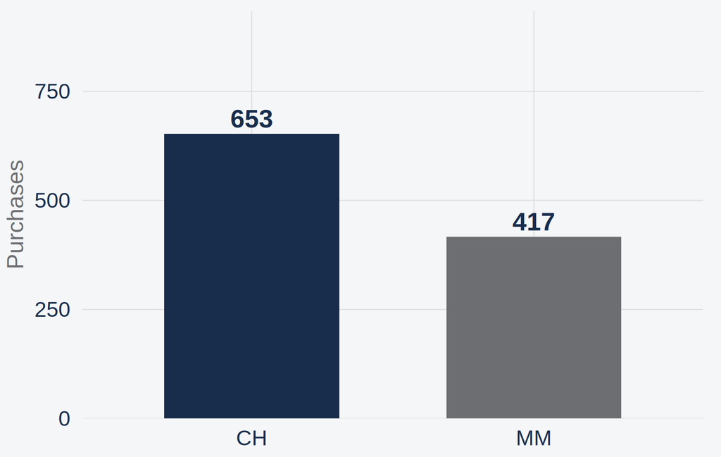

If headquarters only said “most people buy CH,” is that enough for **this** shopper, with a loyalty score and a price gap?

## What is in the file?

| Variable | Type | Unit | Description |
| --- | --- | --- | --- |
| Purchase | CH / MM | brand | Which OJ they bought (Y) |
| LoyalCH | numeric | 0–1 score | Customer loyalty toward Citrus Hill |
| PriceDiff | numeric | dollars | Sale price MM − sale price CH |
| SalePriceCH | numeric | dollars | CH shelf / sale price |
| SalePriceMM | numeric | dollars | MM shelf / sale price |

Workhorses this hour: **LoyalCH** and **PriceDiff**. List prices, discounts, special-display flags, and store ids stay in the file. We will not use them today.

## What we will do today

1. Why a straight line fails for a brand choice, on this file
2. The curve, the odds, and what a coefficient multiplies
3. Fit loyalty, then the price gap with loyalty held fixed
4. Score one new visit — a probability — and stop

## Brand choice is a probability, not a line

This file

We want the chance a shopper buys Citrus Hill. A straight line was built for a number that can sit anywhere — a dollar balance, not a brand.

## Example on OJ — loyal shoppers and CH

- Mean `LoyalCH` ≈ **0.72** among CH buyers.
- Mean `LoyalCH` ≈ **0.32** among MM buyers.
- Loyalty already separates the two brands. We still need a probability.

```r
round(tapply(oj$LoyalCH, oj$Purchase, mean), 2)
```

```
  CH   MM
0.72 0.32
```

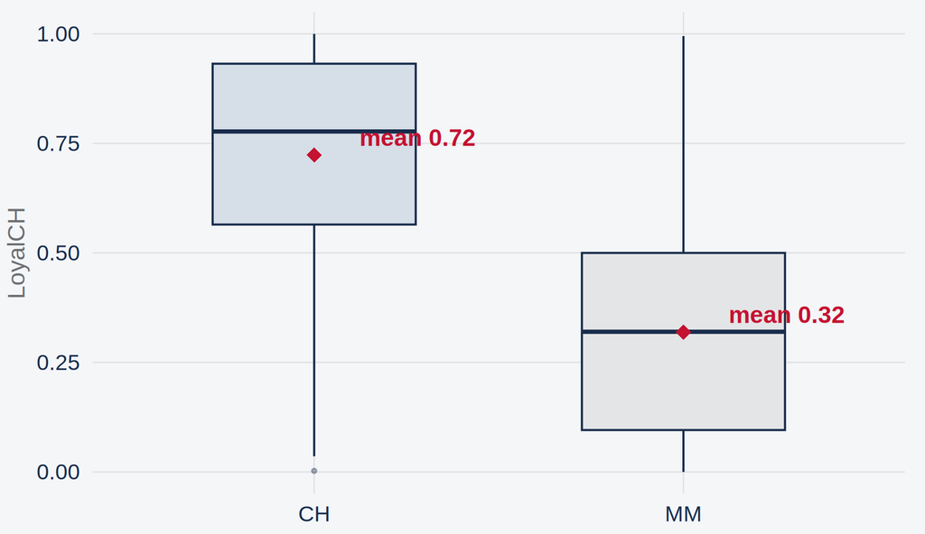

Before any formula: which shopper would you bet on for CH — loyalty near 0.3, or near 0.7?

## Example on OJ — a fitted “chance” of 1.05

- Treat $Y$ like a dollar amount: `lm(y ~ LoyalCH)`.
- On **this** file the fitted values run from about **0.036** to about **1.051**.
- A number above 1, or below 0, is not a chance.

```r
fit_lin <- lm(y ~ LoyalCH, oj)
range(round(predict(fit_lin), 3))
```

```
[1] 0.036 1.051
```

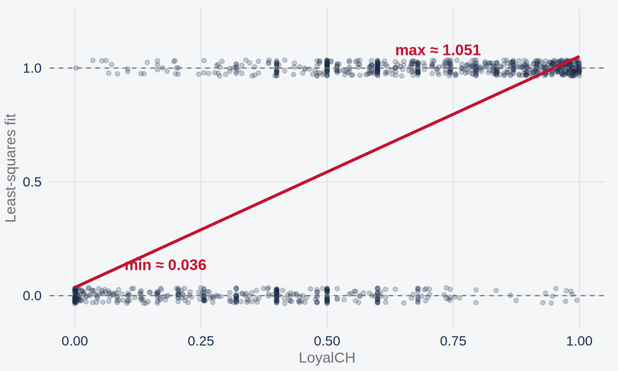

Would you report “1.051 chance of buying CH” to the store?

## Example on OJ — CH share by loyalty bin

The CH rate climbs with loyalty. The steps are not equal.

| LoyalCH | CH rate |
| --- | --- |
| [0,0.2) | 0.12 |
| [0.2,0.4) | 0.28 |
| [0.4,0.6) | 0.53 |
| [0.6,0.8) | 0.77 |
| [0.8,1] | 0.96 |

```r
round(tapply(oj$y, oj$loyal_bin, mean), 2)
```

```
  [0,0.2) [0.2,0.4) [0.4,0.6) [0.6,0.8)   [0.8,1]
     0.12      0.28      0.53      0.77      0.96
```

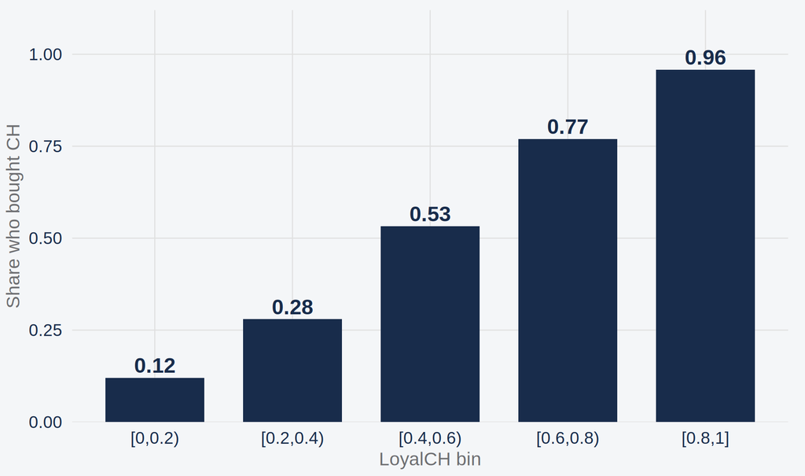

Is the step from the first bin to the second the same size as the step near the top?

## The curve stays between 0 and 1

For a score $\eta$, the logistic function is a probability:

$$p = \frac{e^{\eta}}{1 + e^{\eta}}, \qquad 0 < p < 1.$$

$\eta$ will be a line in the shopper’s features. $p$ is $\mathrm{P}(\mathrm{CH})$ for that shopper.

The function. It cannot cross 0 or 1.

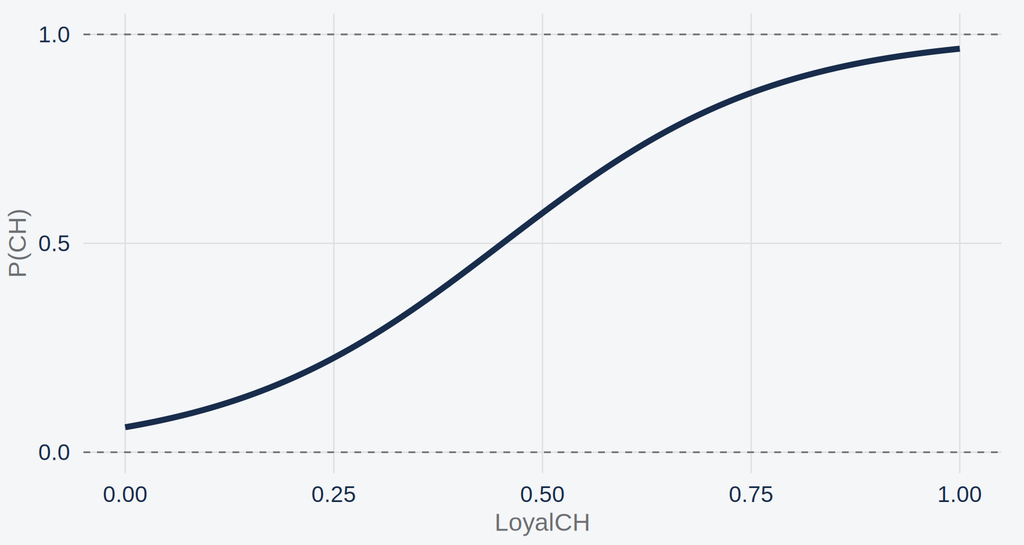

Same curve, with this file’s purchases.

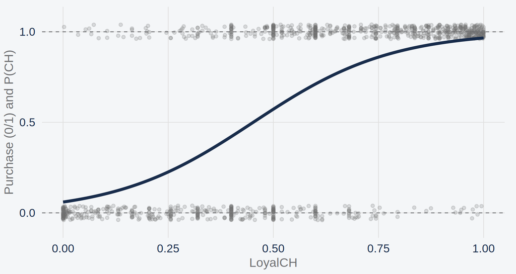

## Odds come out of that function

- If $p = \mathrm{P}(\mathrm{CH})$, the odds of CH are $p / (1 - p)$.
- Substitute the logistic function. The odds equal $e^{\eta}$.
- We still report $p$. The odds are the scale the line is written on.

$$\frac{p}{1-p} = e^{\eta}.$$

If $\eta$ rises by $\log 2$, what happens to the odds of CH?

They double. $p$ does not double. The next slides separate those two.

## This file’s share, on the odds ladder

A probability of 0.61 is not odds of 0.61. On this file the CH share is about **0.61**, so the odds of CH are about **1.56**.

| p = P(CH) | Odds p / (1 − p) | In words |
| --- | --- | --- |
| 0.25 | 0.33 | one to three against CH |
| 0.50 | 1 | even |
| 0.61 | 1.56 | CH share in this file |
| 0.75 | 3 | three to one for CH |

```r
p <- round(mean(oj$y), 2)
round(p / (1 - p), 2)
```

```
[1] 1.56
```

The code prints 1.56. Which row is this file, and which rows are only the language of odds?

## A coefficient multiplies the odds, not $p$

- Write the score as a line: $\eta = \beta_0 + \beta_1 \mathrm{LoyalCH}$.
- A step of size $\Delta$ in loyalty **adds** $\beta_1 \Delta$ to the log-odds.
- That **multiplies** the odds of CH by $e^{\beta_1 \Delta}$.
- It does **not** add $\beta_1 \Delta$ to the probability.

$$\frac{\text{odds after}}{\text{odds before}} = e^{\beta_1 \Delta}.$$

The size of the change in $p$ still depends on where you start. The bins already showed unequal steps.

## What to remember — and what we do next

Remember

- On this file a straight line left (0, 1): about 0.036 to 1.051.
- The logistic curve stays inside (0, 1).
- A coefficient multiplies the **odds**. It does not add a constant to $p$.

Next

- Fit that curve on OJ. Loyalty first.
- Then the price gap, with loyalty held fixed.
- Score **one** new visit as a probability. Stop there.

## R picks the coefficients that fit these purchases

One idea

Maximum likelihood chooses $\beta$ so the CH and MM purchases in this file are as likely as possible under the curve. `glm` does the search. We read the result.

## Example on OJ — loyalty alone

`glm(y ~ LoyalCH)` on this file:

- Intercept ≈ **-2.76**
- LoyalCH ≈ **6.09**

$$\hat\eta = -2.76 + 6.09\,\mathrm{LoyalCH}.$$

```r
fit1 <- glm(y ~ LoyalCH, oj, family = binomial)
round(coef(fit1), 2)
```

```
(Intercept)     LoyalCH
      -2.76        6.09
```

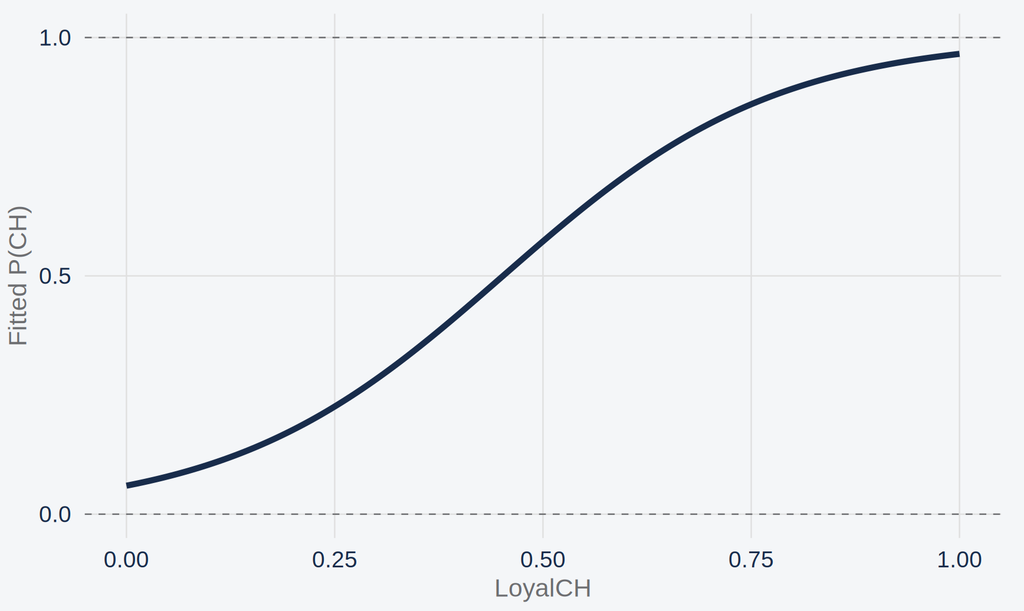

The slope is about 6.09. Is that “+6.09 probability” when loyalty goes from 0 to 1?

## Example on OJ — same +0.1, two changes in $p$

- From the fit you just saw, a **+0.1** step in `LoyalCH` multiplies the odds of CH by about **1.84**.
- That multiplier does not depend on where you start.
- The change in the **probability** does.
- Start at 0.32 (MM buyers’ mean): about **0.31** → **0.45**.
- Start at 0.72 (CH buyers’ mean): about **0.84** → **0.90**.

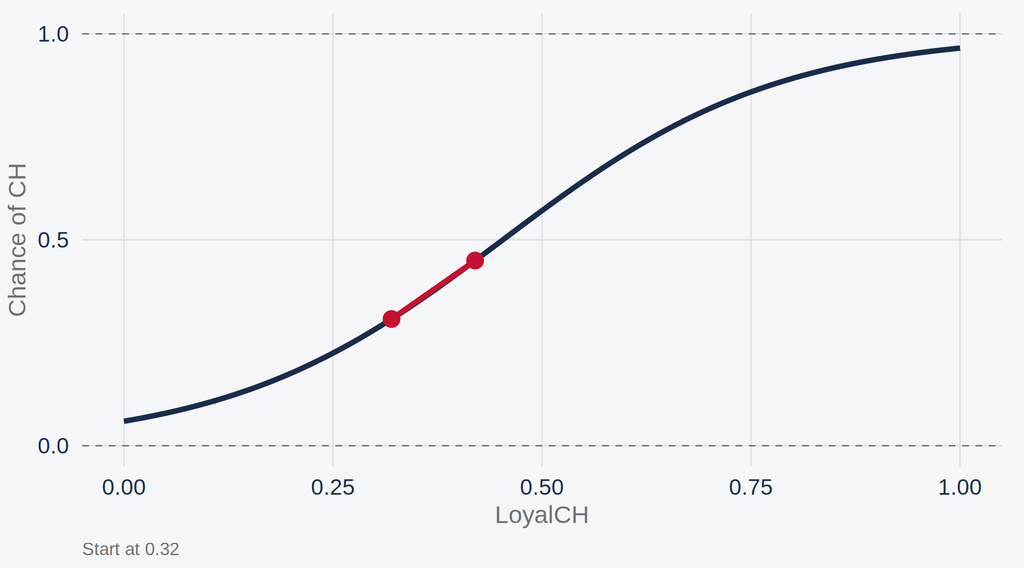

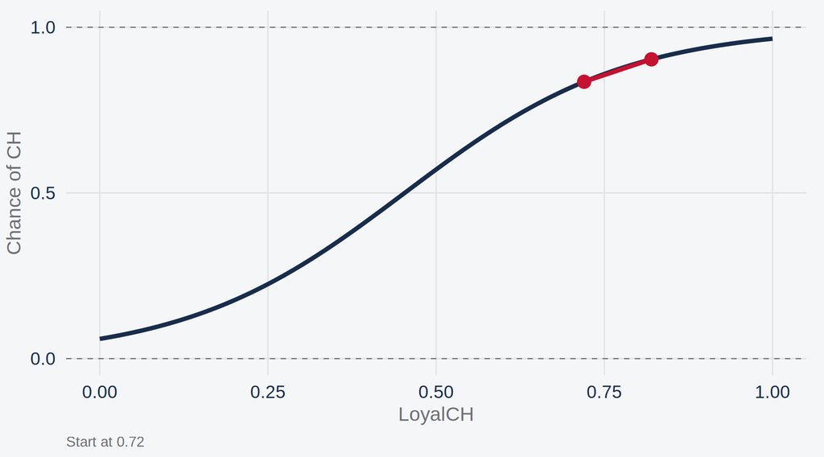

## Add the price gap, loyalty held fixed

Same shopper, different shelf

- PriceDiff = sale price MM − sale price CH.
- The model is now $\hat\eta = \hat\beta_0 + \hat\beta_1 \mathrm{LoyalCH} + \hat\beta_2 \mathrm{PriceDiff}$.
- **Held fixed** means two visits with the same `LoyalCH` and a different price gap.
- On this file: intercept ≈ **-3.25**, LoyalCH ≈ **6.40**, PriceDiff ≈ **2.86**.

```r
fit2 <- glm(y ~ LoyalCH + PriceDiff, oj, family = binomial)
round(coef(fit2), 2)
```

```
(Intercept)     LoyalCH   PriceDiff
      -3.25        6.40        2.86
```

The PriceDiff coefficient is that comparison, on the log-odds scale. It is an association for prediction. It is not a cause.

## Example on OJ — ten cents on the price gap

- Hold `LoyalCH` fixed. Raise PriceDiff by **$0.10** (MM becomes 10 cents more expensive relative to CH).
- The odds of CH are multiplied by about **1.33**.
- At LoyalCH = 0.5, that step moves the chance from about **0.49** to about **0.56**.

$$e^{0.10 \times 2.86} \approx 1.33.$$

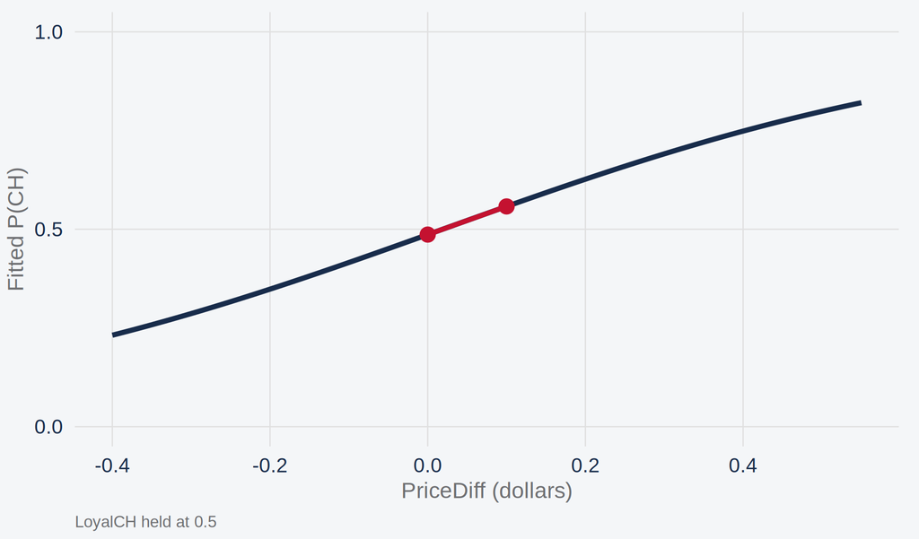

Holding loyalty fixed, does a larger MM–CH price gap push the chance of CH up or down?

## Score one visit by hand

LoyalCH = 0.5, PriceDiff = +0.2

Use the rounded coefficients already on the board.

$$\hat\eta = -3.25 + 6.40(0.5) + 2.86(0.2) = 0.522.$$

$$\hat p = \frac{e^{0.522}}{1 + e^{0.522}} \approx 0.63.$$

```r
new <- data.frame(LoyalCH = 0.5, PriceDiff = 0.2)
round(predict(fit2, new, type = "response"), 2)
```

```
   1
0.63
```

The hand score uses the rounded coefficients. `predict` on the same row agrees at two decimals: about 0.63.

## Example on OJ — same loyalty, opposite price

- LoyalCH 0.5, PriceDiff **+0.2** → $\hat p$ ≈ **0.63**
- LoyalCH 0.5, PriceDiff **−0.2** → $\hat p$ ≈ **0.35**
- LoyalCH 0.9, PriceDiff **0** → $\hat p$ ≈ **0.92**

```r
visits <- data.frame(
  LoyalCH = c(0.5, 0.5, 0.9),
  PriceDiff = c(0.2, -0.2, 0)
)
round(predict(fit2, visits, type = "response"), 2)
```

```
   1    2    3
0.63 0.35 0.92
```

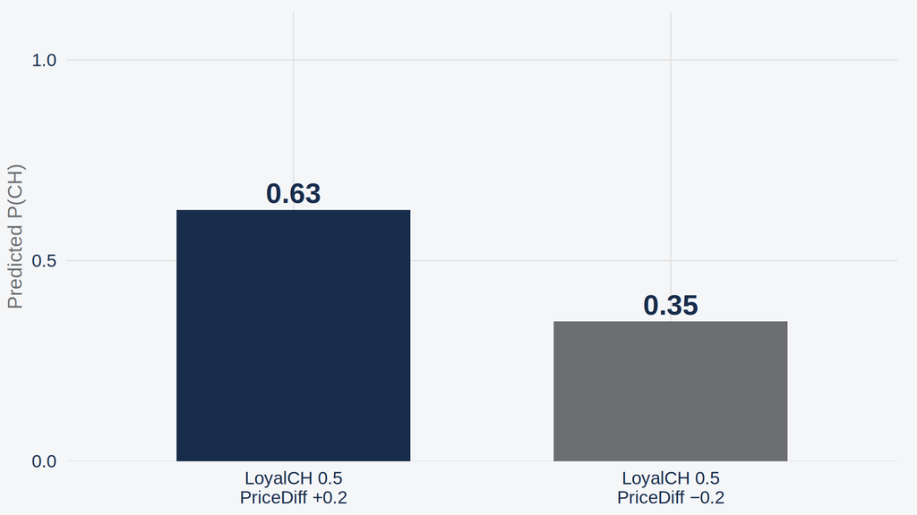

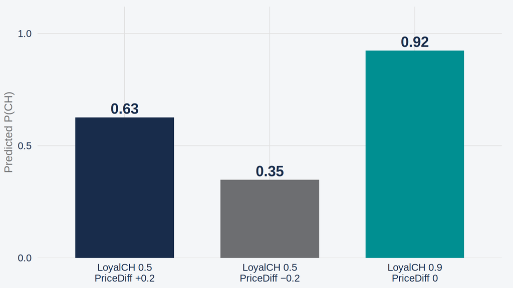

In the first two rows, which lever moved — loyalty, or the price gap?

## What to remember

- CH 653 / MM 417. Mean loyalty **0.72** vs **0.32**.
- A line on 0/1 ran about **0.036** to **1.051**. Bin CH rates: **0.12, 0.28, 0.53, 0.77, 0.96**.
- Loyalty alone: **−2.76 + 6.09 LoyalCH**. A +0.1 step multiplies the odds by about **1.84**.
- With the price gap: **−3.25 + 6.40 LoyalCH + 2.86 PriceDiff**. Ten cents multiplies the odds by about **1.33**.
- LoyalCH 0.5 and PriceDiff +0.2 → about **0.63**. The opposite gap → about **0.35**. LoyalCH 0.9 and a flat gap → about **0.92**.

Can we predict which OJ brand a shopper buys?

A probability for **this** visit, from loyalty and the price gap, between 0 and 1. An association. Not a cause.

## Before next class

1. Midterm **review** is the next methods meeting. The **midterm** is the meeting after that. Closed notes. Weeks 1–5, including logistic.
2. Finish Homework 2 if it is still open, on the schedule.
3. Reading already named: ISLR Chapter 4, the logistic sections.
4. The logistic **R lab** is after fall break. Bring a laptop that day, once it is posted.